# Recla Analysis

Frederick Boehm

2020-06-29

```r
is_inst <- function(pkg) {
    nzchar(system.file(package = pkg))
}
qtl2_indic <- is_inst("qtl2")
knitr::opts_chunk$set(eval = qtl2_indic)
```

```r
library(dplyr)
library(ggplot2)
library(qtl2pleio)
library(qtl2)
```

## Load Recla data from `qtl2data` github repository

```r
file <- paste0("https://raw.githubusercontent.com/rqtl/",
               "qtl2data/master/DO_Recla/recla.zip")
recla <- read_cross2(file)
# make sex a covariate for use in qtl2pleio::scan_pvl
recla[[6]][ , 1, drop = FALSE] -> sex
# insert pseudomarkers
insert_pseudomarkers(recla, step = 0.10) -> pseudomap
gm <- pseudomap$`8`
```

We use the hidden Markov model from Broman (2012a) and Broman (2012b) (as implemented in Broman et al. (2019)) to calculate 36-state genotype probabilities for autosomal markers.

```r
probs <- calc_genoprob(recla, map = pseudomap, cores = 1)
```

We then convert the genotype probabilities to haplotype dosages.

```r
aprobs <- genoprob_to_alleleprob(probs)
```

We calculate kinship matrices, by the “leave one chromosome out (loco)” method.

```r
kinship <- calc_kinship(aprobs, "loco")
```

Before performing our QTL mapping, we transform the phenotypes.

```r
recla$pheno -> ph
log(ph) -> lph
apply(FUN = broman::winsorize, X = lph, MARGIN = 2) -> wlph
as_tibble(wlph) -> wlph_tib
```

We next perform the univariate QTL scan for all phenotypes.

```r
sex2 <- matrix(as.numeric(sex == "female"), ncol = 1)
colnames(sex2) <- "female"
rownames(sex2) <- rownames(aprobs[[1]])
out <- scan1(genoprobs = aprobs,
             pheno = wlph,
             kinship = kinship,
             addcovar = sex2,
             reml = TRUE
             )
```

We want to look closely at those peaks on Chromosome 8. We’ll save the positions of peaks for our two traits of interest.

```r
(peaks <- find_peaks(out, pseudomap, threshold = 5) %>%
  dplyr::arrange(chr, pos) %>%
   dplyr::select(- lodindex))
```

```
##                    lodcolumn chr     pos      lod
## 1                         bw   1 23.9075 5.471580
## 2         OF_distance_first4   1 43.2385 5.772977
## 3             LD_transitions   1 95.8075 5.028258
## 4                OF_distance   2 49.9770 5.544458
## 5                         bw   2 52.3932 7.352334
## 6            OF_immobile_pct   2 53.2646 9.771814
## 7  VC_bottom_distance_first4   2 71.0160 6.531654
## 8         OF_distance_first4   3 10.7360 5.541166
## 9  VC_bottom_distance_first4   3 16.3700 5.518637
## 10           VC_top_time_pct   3 17.9390 5.951067
## 11         LD_distance_light   3 23.4390 5.203246
## 12                        bw   3 24.8390 5.632714
## 13        VC_top_time_first4   3 48.1280 6.144073
## 14           VC_top_velocity   3 48.5630 6.264824
```

[output cut: 63 more lines]

```r
peaks8 <- peaks %>%
  dplyr::filter(chr == 8, pos > 50, pos < 60)
pos_LD_light_pct <- peaks8 %>%
  dplyr::filter(lodcolumn == "LD_light_pct") %>%
  dplyr::select(pos)
pos_HP_latency <- peaks8 %>%
  dplyr::filter(lodcolumn == "HP_latency") %>%
  dplyr::select(pos)
```

## Correlation

Given that the two traits “percent time in light” and “distance traveled in light” share a peak, we want to ask how correlated they are.

```r
cor(wlph[ , 7], wlph[ , 10], use = "complete.obs")
```

```
## [1] 0.8859402
```

```r
cor(wlph[ , 22], wlph[ , 10], use = "complete.obs")
```

```
## [1] -0.1507317
```

```r
cor(wlph[ , 7], wlph[ , 22], use = "complete.obs")
```

```
## [1] -0.143598
```

Since “percent time in light” and “distance traveled in light” are very highly correlated, we’ll discard “distance traveled in light” and perform subsequent analyses with only “percent time in light” and the second trait, “hot plate latency”.

## Scatter plot of phenotypes

We create a scatter plot for the two phenotypes, “hot plate latency” and “percent time in light”.

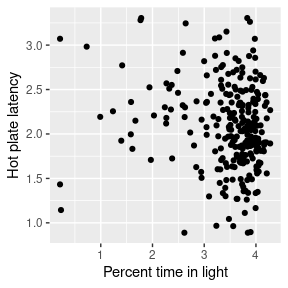

```r
ggplot() +
  geom_point(data = wlph_tib, aes(y = HP_latency, x = LD_light_pct)) +
  labs(x = "Percent time in light", y = "Hot plate latency")
```

## Genome-wide LOD plots for the traits from Recla

Let’s plot the results of the univariate QTL scans for our two traits.

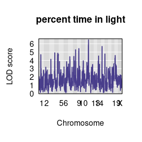

```r
plot(out, map = pseudomap,
     lodcolumn = 10,
     main = "percent time in light"
     )
```

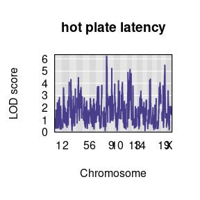

```r
plot(out, map = pseudomap,
     lodcolumn = 22,
     main = "hot plate latency"
     )
```

We examine the allele effects plots for our two traits, in the region of interest on Chromosome 8.

```r
scan1coef(aprobs[ , 8], pheno = wlph[ , 10], kinship = kinship$`8`,
          reml = TRUE,
          addcovar = sex2) -> s1c_10
scan1coef(aprobs[ , 8], pheno = wlph[ , 22], kinship = kinship$`8`,
          reml = TRUE,
          addcovar = sex2) -> s1c_22
```

```r
# subset scan1output objects
s1c_10s <- s1c_10[650:999, ]
# 650:999 is the same as the interval for the two-dimensional scan.
s1c_22s <- s1c_22[650:999, ]
```

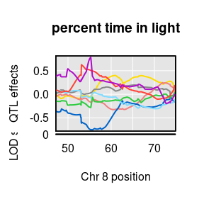

```r
plot_coefCC(s1c_10s, scan1_output = out[ , 10, drop = FALSE], map = pseudomap, main = "percent time in light")
```

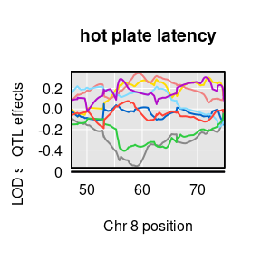

```r
plot_coefCC(s1c_22s, scan1_output = out[ , 22, drop = FALSE], map = pseudomap, main = "hot plate latency")
```

## Two-dimensional scan results from github

We present the code that we ran to perform the two-dimensional scan.

```r
scan_pvl(probs = aprobs$`8`,
         pheno = wlph[, c(10, 22)],
         addcovar = sex2,
         kinship = kinship$`8`,
         start_snp = 650,
         n_snp = 350) -> pvl1022
```

To save computing time, we read the two-dimensional scan results from Zenodo. Because the Zenodo file was created with an older version of `scan_pvl`, it contains the log (natural base) likelihoods, rather than log10 likelihoods. Thus, we’ll want to rectify this, which we do with code below.

```r
as_tibble(read.table("https://zenodo.org/record/3210710/files/recla-10-22.txt?download=1", stringsAsFactors = FALSE)) -> pvl1022
```

We then calculate the likelihood ratio test statistic.

```r
(mylrt <- calc_lrt_tib(pvl1022))
```

```
## [1] 2.771408
```

## Profile LOD Plot

We create a profile LOD plot.

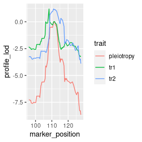

```r
colnames(recla$pheno)[c(10, 22)] <- c("Percent time in light", "Hot plate latency")
pvl1022 %>%
  mutate(log10lik = loglik / log(10)) %>%
  dplyr::select(- loglik) %>%
  calc_profile_lods() %>%
  add_pmap(pmap = recla$pmap$`8`) %>%
  ggplot() + geom_line(aes(x = marker_position, y = profile_lod, colour = trait))
```

## Bootstrap analyses

First, we find the *pleiotropy peak* marker. This is the marker for which the log likelihood is maximized under the constraint of pleiotropy.

```r
find_pleio_peak_tib(pvl1022, start_snp = 650)
```

```
## loglik139
##       788
```

We need the *pleiotropy peak* marker in the bootstrap analyses because it is the marker used in drawing bootstrap samples.

To save computing time, we read the bootstrap results files from Github. For details of how we performed the bootstrap analyses on the University of Wisconsin-Madison Center for High-Throughput Computing, please see the documentation in the qtl2pleio-manuscript repository: https://github.com/fboehm/qtl2pleio-manuscript.

```r
## read boot lrt files
boot_lrt <- list()
for (i in 1:1000){
  n <- i - 1
  fn <- paste0("https://raw.githubusercontent.com/fboehm/qtl2pleio-manuscript-chtc/master/Recla-bootstrap/results/recla-boot-run561_", n, ".txt")
  boot_lrt[i] <- read.table(fn)
}
# convert list to numeric vector
boot_lrt <- unlist(boot_lrt)
```

We get a bootstrap p-value by comparing the above vector’s values to `mylrt`, the test statistic for the observed data.

```r
sum(boot_lrt >= mylrt) / length(boot_lrt)
```

```
## [1] 0.109
```

## References

Broman, Karl W. 2012a. “Genotype Probabilities at Intermediate Generations in the Construction of Recombinant Inbred Lines.” *Genetics* 190 (2): 403–12.

———. 2012b. “Haplotype Probabilities in Advanced Intercross Populations.” *G3: Genes, Genomes, Genetics* 2 (2): 199–202.

Broman, Karl W, Daniel M Gatti, Petr Simecek, Nicholas A Furlotte, Pjotr Prins, Śaunak Sen, Brian S Yandell, and Gary A Churchill. 2019. “R/Qtl2: Software for Mapping Quantitative Trait Loci with High-Dimensional Data and Multiparent Populations.” *Genetics* 211 (2): 495–502.

Logan, Ryan W, Raymond F Robledo, Jill M Recla, Vivek M Philip, Jason A Bubier, Jeremy J Jay, Carter Harwood, et al. 2013. “High-Precision Genetic Mapping of Behavioral Traits in the Diversity Outbred Mouse Population.” *Genes, Brain and Behavior* 12 (4): 424–37.

Recla, Jill M, Raymond F Robledo, Daniel M Gatti, Carol J Bult, Gary A Churchill, and Elissa J Chesler. 2014. “Precise Genetic Mapping and Integrative Bioinformatics in Diversity Outbred Mice Reveals Hydin as a Novel Pain Gene.” *Mammalian Genome* 25 (5-6): 211–22.